# The Nationalization of Congressional Elections

One election, not fifty

Democracy’s Data

Last updated September 13, 2026 at 10:53a EDT

Political scientists have long observed that congressional elections have nationalized.[^1] Voters once weighed the person in front of them: the incumbent who fixed a bridge, the challenger with a familiar name. Now, the observation goes, they vote the national fight from the top of the ballot to the bottom, and a Senate or House race is mostly a referendum on the president.

That matters to anyone who votes. If congressional elections are national, your representative’s own record barely enters your verdict on them, and accountability moves from the person to the party. The textbook states the change as a settled fact. This brief does what this book always does with a settled fact: turns it into a question. Is it true — and if it is, when did it happen, and what exactly moved?

## The test

A split outcome measures the claim. A split outcome is a place that voted one way for president and the other way for another office on the same ballot. A state that backed the Republican for president and elected a Democratic senator is a split outcome; so is a House district that did the reverse. A voter deciding on national grounds votes the same way all the way down, so if elections have nationalized, split outcomes should be getting rarer.

Three records carry that measure back in time. Voteview, the database of every congressional roll-call vote since 1789 maintained at UCLA, keeps a roster of every member of Congress, and that roster says who sat for each state in every Congress since 1879, so a state whose two senators belong to different parties has answered the same question two ways. The *Statistics of the Presidential and Congressional Election*, the volume the Clerk of the House compiles after each federal election from the states’ certified totals, prints each state’s presidential and Senate vote on the same page, for 2004 through 2024. And the house-competition chapter’s file carries the presidential vote inside each congressional district back to 1952, a number no government computes.

All three rest on certified returns, the complete and official record of who won each contest, and the returns chapter explains what such a record can bear. One care is taken with the Senate measure. It is a subtraction, how a state voted for the Senate minus how it voted for president, and a subtraction is exactly where two differently built files leak their differences into the answer. So both numbers come off the Clerk’s one page, compiled by one office from one set of state canvasses on one date.

## The data

Three tables hold the series, and each row is a place at a moment.

`delegations.csv` has one row per Congress from 1879 to 2025, built by reading the Senate rows out of Voteview’s 51,062 member-Congress records. Its columns are `year`, `states`, `split_states` and the share `pct_split`. Party is read as the line the senator ran on and nothing else: an independent is not quietly filed as a Democrat, however they vote in Washington. One complication is cleaned into a companion column. A state that lost a senator mid-term can contribute three people to one Congress, and 298 state-Congresses do. `pct_split_two` recomputes the share over states that sent exactly two senators, the only case where reading the roster as a photograph is safe.

`senate_years.csv` and `senate_contests.csv` come from the Clerk’s six volumes: 204 Senate contests, 2004 through 2024, each with the state’s Senate share, its presidential share and the `gap` between them. The cleaning made two decisions. The 3 contests decided in runoffs are repaired and marked, because a runoff is a different day and a different electorate, and its share cannot sit beside a November presidential share. And in 10 contests one major party ran nobody, so there is no distance to measure; they keep their winner and drop out of the `gap` column.

`house_years.csv` is the House series: 7,177 district-elections across the 19 presidential years from 1952 to 2024. Each year carries `pct_split` and the two quantities it is made of. `wobble` is how far the typical House candidate finished from their own party’s presidential candidate in the same district. `spread` is how far the typical district sits from the middle of that year’s distribution, measured around the year’s own median — the middle district, with half the districts above it and half below — so a landslide does not read as districts moving apart. `swap.csv` holds one small experiment described below.

Here is the roster series at three points, a century and a half apart:

| Congress | Convened | States | Split delegations | Share |
| --- | --- | --- | --- | --- |
| 46th | 1879 | 38 | 7 | 18.4% |
| 96th | 1979 | 50 | 27 | 54.0% |
| 119th | 2025 | 50 | 4 | 8.0% |

> **Before you read on, write down a prediction.** In 1984, 40.3% of congressional districts voted one way for president and the other way for the House. In 2024 it was 4.0%. **Which of these two things do you think did more of that work?** That House candidates stopped finishing far from their party’s presidential candidate, or that districts themselves moved further from the point where the country divides evenly. Write down which, and roughly how much of the fall you would give it.

## What it says about democracy

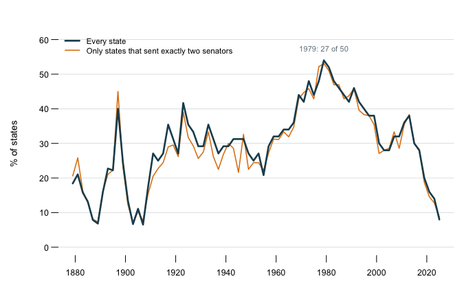

Move across the figure for a Congress-by-Congress readout.

**Figure 1. States whose two senators belonged to different parties, 1879 to 2025.** Two lines on a time axis, because the claim is a claim about change and the answer is a shape. The heavy line uses every state; the light line uses only states that sent exactly two senators. The two agree, correlating at 0.9783 (where 1 would mean they move in lockstep) and differing by a median of 1.4 points, so the mid-term replacements are not driving the answer.

The shape is a hill. Split delegations — a state’s two Senate seats held by different parties — were ordinary for most of the twentieth century, and they ran to a peak in 1979, when 27 of 50 states, 54.0% of them, sent two senators from different parties. Then they fell for forty-five years. In 2025 there are 4: ME, PA, VT, WI.

A roster describes a moment that six years of elections produced. The Clerk’s volumes ask the same question one election day at a time:

| Election | Senate contests | Split outcomes | Share | Both parties ran | Distance from the ticket |
| --- | --- | --- | --- | --- | --- |
| 2004 | 34 | 7 | 20.6% | 33 | 9.44 |
| 2008 | 33 | 7 | 21.2% | 32 | 5.24 |
| 2012 | 33 | 8 | 24.2% | 32 | 5.32 |
| 2016 | 34 | 0 | 0.0% | 32 | 4.63 |
| 2020 | 35 | 1 | 2.9% | 32 | 1.46 |
| 2024 | 35 | 6 | 17.1% | 33 | 2.16 |

Two columns of that table point in opposite directions. The last column, the typical distance between a state’s Senate result and its presidential result on the same ballot, falls from 9.4 points in 2004 to 2.2 in 2024. The count of split outcomes does not fall with it: it runs 7, 7, 8, 0, 1, 6 across the six elections.

The exceptions are worth their story. In 2016 there were none at all, the first presidential election since senators became popularly elected in 1913 in which every state that elected a senator elected one from the party that carried it.[^2] Eight years later there were 6. Nationalization did not reverse between 2016 and 2024. Thirty-odd contests is too few for a count of crossings to be steady, and a count of crossings is a different thing from the distance underneath it.

The House series has enough contests to hold that distinction up to the light.

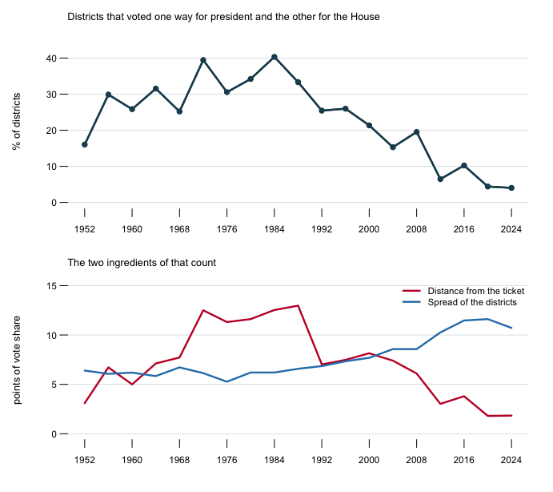

Move across either panel for an election-by-election readout.

**Figure 2. 19 presidential elections, 7,177 district-elections.** Only presidential years are drawn, so every point compares a House election with the presidential election held the same day. The top panel is the share of districts that split. The bottom panel holds the two quantities that count is made of.

The top panel is the finding everybody quotes: split districts run to **40.3% in 1984** and fall to **4.0% in 2024**. The bottom panel is why. The distance from the ticket was 12.5 points in 1984 and is 1.8 now, smaller by a factor of 6.8. The spread of the districts went the other way, from 6.2 points to 10.7. A district splits when the first number beats the second in the direction that crosses the fifty-per-cent line. Follow the typical district through that. In 1984 the typical district sat 6.2 points from the middle, so its presidential nominee took about 56.2% there; a House candidate of the same party finishing the typical 12.5 points behind the ticket lands at 43.7%, under half, and the district splits. In 2024 the typical district sits 10.7 points out and the typical candidate trails the ticket by only 1.8, landing at 58.9%: no split, with room to spare. Both moved, and both moved the way that makes splitting harder, so the count alone cannot say which did the work.

The swap experiment in `swap.csv` can. Take 1984’s districts and keep their presidential vote exactly as it was: the same country, the same lines, the same landslide. Now give those districts 2024’s candidates: each district keeps its rank, but takes the distance from the ticket at the same rank in the other year. Count the splits again. Nothing is simulated and nothing is random, and handing a year its own distances back reproduces its own count exactly, which is the check that the swap does what it says.

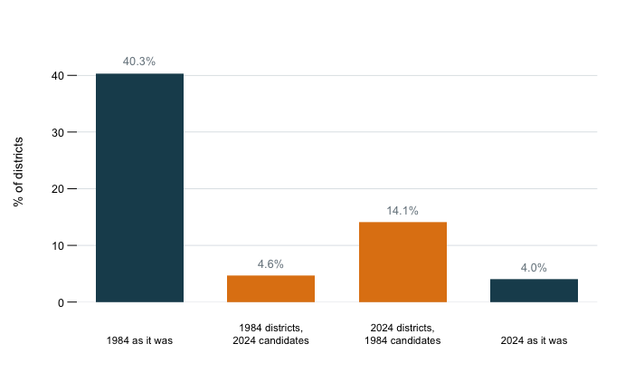

**Figure 3. The same districts, other years’ candidates.** The two dark bars are the elections as they happened. The two light bars are each year’s districts run with the other year’s candidates.

Changing the candidates alone takes 1984 from 40.3% down to 4.6%, almost the entire fall, without moving a single district. Changing the districts alone takes 2024 from 4.0% up to 14.1%, a large move the other way. So the honest answer is not one cause. But the two are not equal: the candidates alone land within 0.6 points of where the country actually is, and the districts alone land 10.1 points away.

The count told you none of this. “Split districts fell from 40.3% to 4.0%” is true and quoted constantly, and it is a threshold: a line drawn at fifty per cent with a yes or a no on either side. Two different quantities moved underneath it, and the threshold reports their combination as one number. When a share of cases crosses a line, ask what would have to change for a case to land on the other side. There is usually more than one answer, and the count gives you none of them.

## What this brief cannot tell you

**No voter appears anywhere in it.** Every number is a total for a place. In a district that split, many people may have split their ballots, or two different sets of people turned out for the two contests. Guessing what individuals did from group totals is called ecological inference, and it has its own chapter.

**The roster measure and the returns measures are not the same measurement.** Figure 1 counts states by who was sitting; the Clerk’s table counts contests by who was elected. A state can look split in the roster for six years on the strength of one election, so the series are not expected to agree year for year. And the Senate returns series is six elections long, an order rather than a trend, which is why the House series carries the weight.

**The swap is a re-ranking, not a world.** It says what the count would be if the distances between House candidates and their tickets were distributed as in another year. It does not claim any particular district would have gone the other way.

**Party is the ballot line throughout.** Read the Senate by who sits with whom in Washington instead, and the last Congress holds 3 split states rather than 4.

**The claim reaches further than the record does.** Nationalization is also a claim about governors, legislatures and school boards, where a voter leaning on the party label is voting nationally whether they mean to or not. No national office collects those results, so the claim is best measured exactly where it is least surprising.

## What you should have learned

- Split Senate delegations peaked in 1979 at 27 of 50 states and have fallen to 4 in 2025 — the textbook’s claim is true in the roster, and the fall took decades.
- Split House districts fell from 40.3% in 1984 to 4.0% in 2024, across 7,177 district-elections.
- Two quantities moved under that count: the typical House candidate’s distance from the ticket shrank by a factor of 6.8, while the spread of the districts grew from 6.2 to 10.7 points.
- Swapping in today’s candidates alone takes 1984 from 40.3% to 4.6%; a count of threshold crossings hides which ingredient did the work.
- A count of split outcomes can be noisy while the distance underneath it moves steadily: the Senate produced 0 splits in 2016 and 6 in 2024 without nationalization reversing.

## Extensions

None of these is answered above, and every one can be answered from the tables the Sources section hands over.

- `delegations.csv` gives `pct_split` for every Congress across a century and a half. Follow it backward. Was there ever a time when states routinely sent two senators of different parties?
- `house_years.csv` carries `wobble` and `spread` alongside `pct_split`. Which of the three is the best single measure of nationalization, and why?
- `senate_contests.csv` has a `gap` between the Senate and presidential result in each state. Sort by it. Which senators still outrun their party, and where?
- `delegations.csv` distinguishes `pct_split` from `pct_split_two`. Compare them decade by decade. How much does the handling of a few mid-term replacements change the story?

Two stretch ideas point past the spreadsheet. Pick one state, download its certified returns for a down-ballot office such as attorney general, and compute that office’s distance from the presidential ticket — the measure this brief could not extend below Congress. And the Clerk’s volumes run much further back than 2004: download an older one and see whether the Senate distance was ever as large as the House distance of the 1970s.

## Sources

**Data**

- Lewis, Jeffrey B., Keith Poole, Howard Rosenthal, Adam Boche, Aaron Rudkin and Luke Sonnet. *Voteview: Congressional Roll-Call Votes Database*, `HSall_members.csv`, one row per member per Congress since 1789, downloadable from Voteview’s data page, https://voteview.com/data; the rosters-source chapter is about what a roster is and is not. https://voteview.com/static/data/out/members/HSall_members.csv
- U.S. House of Representatives, Office of the Clerk. *Statistics of the Presidential and Congressional Election*, the volumes for 2004 through 2024, from which each state’s presidential and Senate vote was read; the house-competition chapter holds the copies. The 2024 Senate contests were also read independently in the crossover chapter, and the two readings agree on every contest. https://clerk.house.gov/Votes/ElectionStatistics; every volume back to 1920 is listed at https://history.house.gov/Institution/Election-Statistics/
- The House series, 1952 to 2024, is the house-competition chapter’s file, built from Gary Jacobson’s House elections data, the Clerk’s volumes and The Downballot’s presidential results by congressional district. No government agency computes that last number. https://www.the-downballot.com/p/the-downballots-calculations-of-presidential

**The data itself**

Every figure above is drawn from these tables. They are plain CSV, they open in a spreadsheet, and they are yours to take further.

`delegation_states.csv`, `delegations.csv`, `house_years.csv`, `senate_contests.csv`, `senate_years.csv`, `swap.csv`

Two more files here are not data about the subject at all – they are how this chapter checked its own work: `facts.csv`, the individual numbers the text above quotes, and `checks.csv`, the arithmetic verified before anything was drawn.

Rebuild this data yourself, with an AI assistant

```
I want to rebuild a public dataset from its original sources, without
any starting files. Please do the following and show your work.

THE FIRST SOURCE. Voteview's congressional member file:
https://voteview.com/static/data/out/members/HSall_members.csv
One CSV, about 6 MB. Each row is one member serving in one Congress,
1789 to the present, with the state and a numeric party code. No
account or key is needed.

THE SECOND SOURCE. The Office of the Clerk of the U.S. House,
"Statistics of the Presidential and Congressional Election", the
official compilation of the state canvasses. One PDF per general
election; you want the presidential years 2004, 2008, 2012, 2016,
2020 and 2024, from https://clerk.house.gov/Elections
There is no CSV and no API. Each volume is a document typeset for a
human, and the presidential vote and the Senate vote for a state sit
on the same pages.

HOW TO READ THE CLERK'S PDFs. Convert each one to text and parse the
text. Four things will go wrong if you do not plan for them. A state
name sits alone on a line, but the line begins with a form feed
wherever the state starts a page. New Jersey in 2004 carries a
footnote marker in its heading, so the heading reads "NEW JERSEY 1".
Minnesota and North Dakota label their Democratic presidential line
"Democratic-Farmer-Labor" and "Democratic-Nonpartisan League", so an
exact match on "Democratic" loses those two states entirely. And a
state that held a runoff prints two columns of votes, which overlap
in the text: what survives is the first digit of the first-round
total and the whole second-round total, stranded on a line of its
own with no name attached. Louisiana in 2016 and Georgia in 2020 are
the three contests affected, and read literally they say a candidate
received one vote.

WHAT TO BUILD.
1. From Voteview: for every Congress since the 46th, the share of
   states whose senators did not all run on the same party line.
   Compute it twice — over every state, and over only the states
   that sent exactly two senators to that Congress.
2. From the Clerk's volumes: one row per Senate contest, carrying
   the state's two-party presidential vote and its two-party Senate
   vote, both taken off the same page.
3. The share of Senate contests won by the party that did not carry
   the state for president, election by election.

CHECK YOUR WORK. The copies this book used were downloaded in August
2026. If your rebuild matches them, you should find:
- 51,062 member-Congress rows in the Voteview file
- 7,458 of them Senate rows for the fifty states from 1879 on,
  covering 3,536 state-Congresses, of which 298 hold three or more
  senators because somebody arrived mid-term
- split delegations peaking at 54% of states in 1979 and standing at
  4 states in 2025
- 204 Senate contests across the six presidential-year volumes, with
  none at all won against the presidential result in 2016
Voteview regenerates its file continuously and each new Congress
adds rows, so a higher row count or a top Congress past 119 means
the file grew rather than that you made an error.
```

[^1]: The fullest statement of the claim is Daniel J. Hopkins, *The Increasingly United States: How and Why American Political Behavior Nationalized* (Chicago: University of Chicago Press, 2018), https://press.uchicago.edu/ucp/books/book/chicago/I/bo27596045.html.
[^2]: Eric Ostermeier, “How Many States Will Split Their Presidential and US Senate Vote in 2020?,” *Smart Politics*, 5 October 2020, https://smartpolitics.lib.umn.edu/?p=457089. Senators have been chosen by popular vote since the Seventeenth Amendment took effect in 1913: https://www.law.cornell.edu/constitution/amendmentxvii.